# Pitcher card

# Beck Way

RHP · KC

2026 · 19 G (1 GS) · 389 pitches · Jun 05 – Jul 24, 2026

Independent portfolio sample by Devin Jenkinson, not affiliated with any club. Every number is computed from public Statcast data.

Three big takeaways

1Watch

The sweeper is his most-used two-strike pitch.

34% of two-strike pitches · 17 two-strike swings so far

No pitch has 50+ two-strike swings yet, so this card does not name a put-away pitch by miss rate.

2Watch

xRV/100 +0.79 shrunk · 165 pitches

Shrunk toward the league average for the pitch type (250-pitch prior), so small edges are real but modest.

3Watch

Build the cutter sample before setting a height plan.

7 swings up · 52 swings down

Rates under 50 swings are not quoted on this card.

Charts

### Movement

The SI finishes 20 in from his FC, with 20 in more arm-side run.

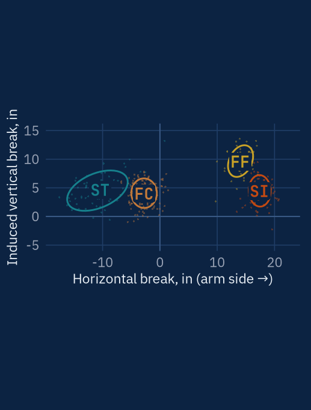

n = 376 pitches. Ellipses hold about 68% of each type; codes sit at the averages.

### Location by count

He throws 48% of pitches in the zone when behind and 54% when ahead.

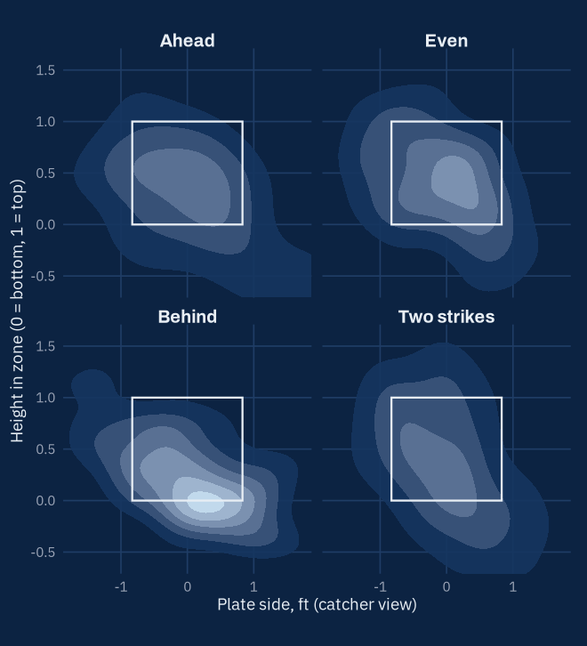

n = 376. Ahead 48 · even 143 · behind 83 · two strikes 102 pitches. Box = rule-book zone.

### Put-away

The ST is 34% of two-strike pitches vs 15% overall.

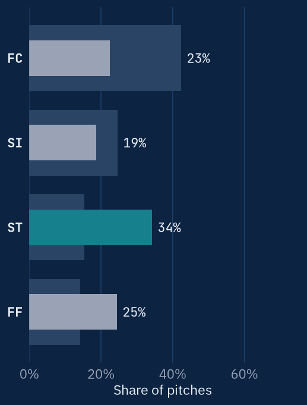

Two-strike n: ST 35, FF 25, FC 23, SI 19. Grey bars = overall usage; wh = whiffs per swing (shown with 50+ swings).

### Arsenal

| Pitch | # | Use | Velo | IVB | HB | VAA | Whiff | Chase | xwOBAcon | xRV/100 | Stuff+ |
| --- | --- | --- | --- | --- | --- | --- | --- | --- | --- | --- | --- |
| Cutter (FC) | 165 | 42% | 91.3 | 4.0 | -2.8 | -6.5 | 34% | 39% | .368 | +0.79 | 108 |
| Sinker (SI) | 96 | 25% | 96.8 | 4.4 | +17.4 | -5.9 | 7% | 24% | .365 | -0.66 | 101 |
| Sweeper (ST) | 60 | 15% | 88.2 | 4.7 | -10.4 | -6.9 | 27% | 25% | .220 | +0.15 | 118 |
| 4-Seam (FF) | 55 | 14% | 97.4 | 9.6 | +14.0 | -4.9 | 24% | 23% | .634 | -1.35 | 89 |

IVB / HB in inches (HB + = arm side). VAA in degrees at the front of the plate. xRV/100 = expected run value per 100 pitches, pitcher’s view, shrunk with a 250-pitch prior. Stuff+ = this project’s shape-only model (100 = MLB average, 10 = 1 SD).

### Vs. batter hand

| Pitch | LHH # | Use | Whiff | xwOBAcon | RHH # | Use | Whiff | xwOBAcon |
| --- | --- | --- | --- | --- | --- | --- | --- | --- |
| FC | 82 | 43% | – | .462 | 83 | 45% | – | .238 |
| SI | 42 | 22% | – | .496 | 54 | 29% | – | .263 |
| ST | 24 | 12% | – | .762 | 36 | 20% | – | .042 |
| FF | 44 | 23% | – | .322 | 11 | 6% | – | .746 |

Use = share of pitches to that side. Whiff = whiffs per swing, shown with 50+ swings.